# Quantitative proteomics - k-means clustering

Author

Thomas Naake

This example performs k-means clustering on the discovery cohort data set of the publication by Jayavelu et al. (2022): “The proteogenomic subtypes of acute myeloid leukemia” (doi: 10.1016/j.ccell.2022.02.006).

k-means clustering is a popular algorithm used for partitioning a dataset into k distinct, non-overlapping subsets or clusters. The main idea is to define clusters such that the data points within each cluster are more similar to each other than to those in other clusters, based on some distance metric (commonly Euclidean distance).

## How k-means clustering works

1. Initialization:
- choose the number of clusters k,
- randomly select k initial cluster centroids (these can be random points from the data or selected through other methods)
2. Assignment Step:
- assign each data point to the nearest cluster centroid. This is typically done using the Euclidean distance,
- each point is now assigned to a cluster based on the closest centroid
3. Update Step:
- recalculate the centroids of the clusters. The new centroid is the mean of all the points assigned to that cluster,
- update the positions of the centroids to these new mean positions
4. Iteration:
- repeat the assignment and update steps until convergence. Convergence is reached when the assignments no longer change or change very little, or after a fixed number of iterations

# Load libraries

```r
## for preprocessing
if (!requireNamespace("MatrixQCvis", quietly = TRUE))
    BiocManager::install("MatrixQCvis")
library("MatrixQCvis")
if (!requireNamespace("SummarizedExperiment", quietly = TRUE))
    BiocManager::install("SummarizedExperiment")
library("SummarizedExperiment")

## for GSEA
if (!requireNamespace("clusterProfiler", quietly = TRUE))
    BiocManager::install("clusterProfiler")
library("clusterProfiler")
if (!requireNamespace("org.Hs.eg.db", quietly = TRUE))
    BiocManager::install("org.Hs.eg.db")
library("org.Hs.eg.db")
if (!requireNamespace("AnnotationDbi", quietly = TRUE))
    BiocManager::install("AnnotationDbi")
library("AnnotationDbi")
if (!requireNamespace("biomaRt", quietly = TRUE))
    BiocManager::install("biomaRt")
library("biomaRt")
```

# Load data set and perform preprocessing

The data set was downloaded from PRIDE database under the ID PXD023201. Here, we will load the dataset and prepare it for analysis.

```r
dia <- read.delim("https://raw.githubusercontent.com/tnaake/AI_MS/main/exercise/data/pxd023201_AML_DIA_proteome.txt",
    sep = "\t", header = TRUE)

## create colData
cD <- dia[1:4, ]
cD <- cD[, grepl(x = colnames(cD), pattern = "AML")] |>
    t() |>
    DataFrame()
colnames(cD) <- c("Type", "Group1", "OSTM", "EFTM")
cD[1, 1] <- "E"
cD[1, 2] <- "Primary"
cD[1, 3] <- "52.01"
cD[1, 4] <- "11.576"
cD$name <- rownames(cD)

## create assay
a <- dia[-c(1:4), grepl(x = colnames(dia), pattern = "AML")] |>
    as.matrix()
mode(a) <- "numeric"
rownames(a) <- dia[-c(1:4), "PG.UniProtIds"]

## create rowData
rD <- dia[-c(1:4), !grepl(x = colnames(dia), pattern = "AML")]
rownames(rD) <- rownames(a)

## create SummarizedExperiment object
dia <- SummarizedExperiment(assays = list(normalized = a), colData = cD, rowData = rD)
```

Remove constant/zero variance proteins (rows).

```r
nas <- dia |>
    assay() |>
    apply(MARGIN = 1, FUN = sd, na.rm = TRUE)
nas[is.na(nas)] <- 0
dia <- dia[nas > 0, ]

## what are the dimensions?
dim(dia)
```

```
[1] 6523  204
```

Keep proteins with more than 80% measured values.

```r
measured <- apply(assay(dia), 1, function(rows_i) sum(!is.na(rows_i)))
dia <- dia[measured > (ncol(dia) * 0.80), ]

## what are the dimensions?
dim(dia)
```

```
[1] 4952  204
```

## Perform QA/QC

```r
shinyQC(dia)
```

Some samples look a bit off (e.g. based on number of missing values, ECDF, dimension reduction plot). Remove them in the following.

```r
.selection <-  c(
    "AML_293", "AML_310", "AML_334", "AML_301", "AML_309", "AML_304")
dia <- MatrixQCvis:::selectSampleSE(dia,
    selection = .selection, mode = "exclude")
```

# Perform k-means clustering

Perform k-means clustering. Iterate over several values of k and store the total within sum-of-squares per iteration.

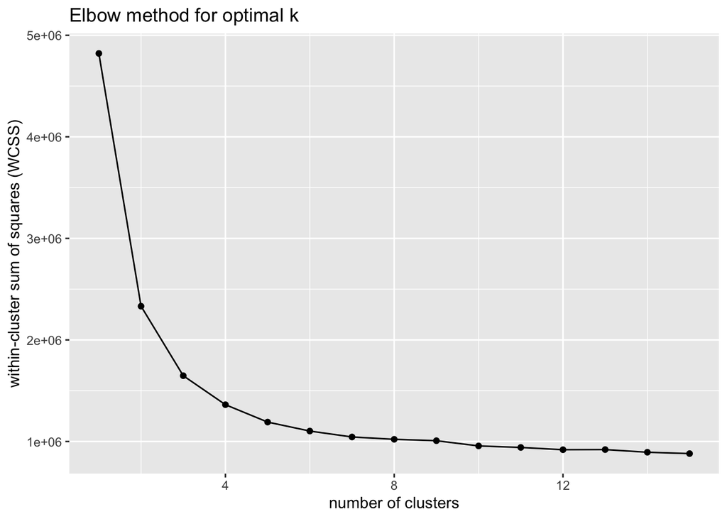

```r
## k-means requires complete datasets, impute using MinDet
assay(dia, "imputed") <- dia |>
    assay() |>
    imputeAssay(method = "MinDet")

## create vector to store results
ks <- 15
wcss <- numeric(ks)

## iterate over several values of k
for (k in seq_len(ks)) {
    model <- kmeans(assay(dia, "imputed"), centers = k,
        iter.max = 10000)
    wcss[k] <- model$tot.withinss
}

## visaulize Elbow method
ggplot(data.frame(k = seq_len(ks), wcss = wcss), aes(x = k, y = wcss)) +
    geom_point() +
    geom_line() +
    ggtitle("Elbow method for optimal k") +
    xlab("number of clusters") +
    ylab("within-cluster sum of squares (WCSS)")
```

## Determine final clusters

According to the “elbow”, the optimal number of clusters is 3 or 4.

Run again the k-means algorithm with `k = 4`.

```r
model <- kmeans(assay(dia, "imputed"), centers = 4,
    iter.max = 10000)
```

Show the distribution of clusters:

```r
table(model$cluster)
```

```
   1    2    3    4
1151  379 1954 1468
```

# Perform enrichment

Convert UniProt ids to Entrez gene ids.

Translation of UNIPROT into gene names, ENSEMBL gene ids, and ENTREZ gene ids.

To facilitate the biological interpretation, we will translate here the UNIPROT ids into SYMBOL, ENSEMBLE and Entrezgene IDs.

Get the IDs from `biomaRt`.

```r
## find the suitable genome
ensembl <- useEnsembl(biomart = "genes", dataset = "hsapiens_gene_ensembl")
.datasets <- listDatasets(ensembl)
.datasets[grep(.datasets$version, pattern = "GRCh38"), ]
```

```
                 dataset              description    version
80 hsapiens_gene_ensembl Human genes (GRCh38.p14) GRCh38.p14
```

```r
mart <- useMart(biomart = "ENSEMBL_MART_ENSEMBL",
    dataset = "hsapiens_gene_ensembl")

## go through the individual datasets and translate the ids
.attributes <- c("ensembl_gene_id", "hgnc_symbol",
    "external_gene_name","uniprot_gn_id", "entrezgene_id")
```

Do then the actual translation for `dia`.

```r
## dia
query <- rownames(dia) |>
    strsplit(split = ";") |>
    lapply(function(gene_i) unique(stringr::str_remove(gene_i, pattern = "[-][0-9]+")))
bm <- getBM(attributes = .attributes, filters = "", mart = mart)
.names <- lapply(query, function(gene_i) {
    inds <- which(bm[, "uniprot_gn_id"] %in% gene_i)
    apply(bm[inds, ], 2, function(cols_j) {
        ids <- cols_j |>
            unique() |>
            stringr::str_trim(side = "both")
        ids <- ids[!is.na(ids)]
        ids[1]
    })
})
.names_df <- do.call("rbind", .names)
colnames(.names_df) <- paste0("biomaRt_", colnames(.names_df))
rowData(dia) <- rowData(dia) |>
    cbind(.names_df)
```

Look into cluster 1.

```r
cluster <- 1
universe <- rowData(dia)[names(model$cluster), "biomaRt_entrezgene_id"]
fg <- names(model$cluster[model$cluster == cluster])
fg <- rowData(dia)[fg, "biomaRt_entrezgene_id"]
```

Perform GSEA.

```r
gsea_results <- enrichGO(gene = fg, universe = universe,
    OrgDb = org.Hs.eg.db, ont = "BP" )
```

Visualize the results.

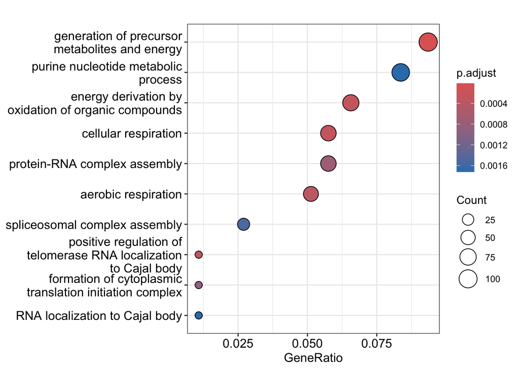

```r
dotplot(gsea_results)
```